# Practical Machine Learning

### Course Project by Lio1

### Human Activity Recognition (HAR) dataset

**Objective:** Predicting the manner (“classe” variable) in which the exercise was done

### Data wrangling

We read the data and turn the “classe” variable to factor

```r
rawTrain <- read.csv("pml-training.csv")
rawTest <- read.csv("pml-testing.csv")
rawTrain$classe <- as.factor(rawTrain$classe)
```

We factor variables

```r
levels(rawTest$user_name) <- levels(rawTrain$user_name)
levels(rawTest$cvtd_timestamp) <- levels(rawTrain$cvtd_timestamp)
levels(rawTest$new_window) <- levels(rawTrain$new_window)
```

We investigate which variables have missing values

```r
sum(sapply(rawTrain,anyNA))
```

```
## [1] 67
```

```r
sum(sapply(rawTest,anyNA))
```

```
## [1] 100
```

We extract variables that do not have NA’s in the test set (60 vars)

```r
NAcols <- names(sapply(rawTest,anyNA)[sapply(rawTest,anyNA)==F])
test <- rawTest[,NAcols]
```

Same operation in the train set + keeping the “classe” column

```r
train <- rawTrain[,c("classe",NAcols[1:59])]
```

We do a final check on NA’s

```r
sum(sapply(train,anyNA))
```

```
## [1] 0
```

```r
sum(sapply(test,anyNA))
```

```
## [1] 0
```

We remove the useless variable “X”

```r
train$X <- NULL
test$X <- NULL
```

### Data Partition

We split the train set provided into a sub train set (75%) and a sub validation set (25%)

```r
library(caret)
set.seed(777)
inTrain1 <- createDataPartition(train$classe,p=0.75,list=F)
train1 <- train[inTrain1,]
train2 <- train[-inTrain1,]
```

### Machine Learning Algorithm

We run a randomForest model and we’ll use the built-in out-of-bag error estimation (Cross Validation)

*Random Forest is a good choice of prediction algorithm for a problem (like this one) where we value accuracy over interpretability

*The automatic calculation of the OBB error rate also makes it easy to cross-validate model accuracy without using the caret package

```r
set.seed(777)
library(randomForest)
set.seed(777)
model1 <- randomForest(classe~.,data=train1)
```

### Out-of-sample error rate

```r
print(model1) #
```

```
##
## Call:
##  randomForest(formula = classe ~ ., data = train1)
##                Type of random forest: classification
##                      Number of trees: 500
## No. of variables tried at each split: 7
##
##         OOB estimate of  error rate: 0.08%
## Confusion matrix:
##      A    B    C    D    E  class.error
## A 4184    1    0    0    0 0.0002389486
## B    0 2848    0    0    0 0.0000000000
## C    0    3 2563    1    0 0.0015582392
## D    0    0    3 2408    1 0.0016583748
## E    0    0    0    3 2703 0.0011086475
```

Our estimated OOB error rate is **0.08%** which is **extremely low**

### Variable importance

**cvtd_timestamp** and **raw_timestamp_part_1** are the top2 variables in termes of importances measured by the Mean Decrease in Gini Index

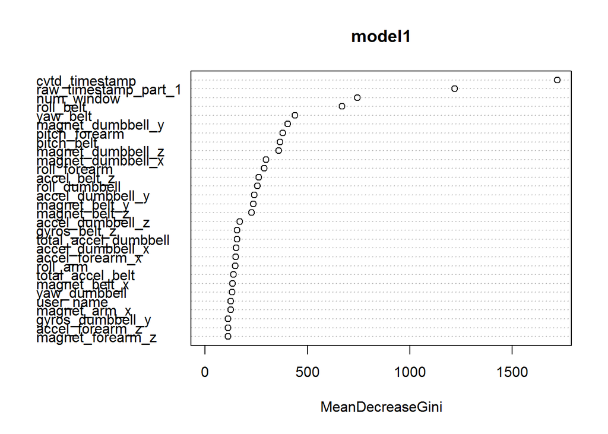

### Model validation

We validate model1 on our sub-validation set

```r
predictVal <- predict(model1,newdata=train2)
confusionMatrix(predictVal,train2$classe)
```

```
## Confusion Matrix and Statistics
##
##           Reference
## Prediction    A    B    C    D    E
##          A 1395    2    0    0    0
##          B    0  947    0    0    0
##          C    0    0  855    1    0
##          D    0    0    0  803    0
##          E    0    0    0    0  901
##
## Overall Statistics
##
##                Accuracy : 0.9994
##                  95% CI : (0.9982, 0.9999)
##     No Information Rate : 0.2845
##     P-Value [Acc > NIR] : < 2.2e-16
##
##                   Kappa : 0.9992
##  Mcnemar's Test P-Value : NA
##
## Statistics by Class:
##
##                      Class: A Class: B Class: C Class: D Class: E
## Sensitivity            1.0000   0.9979   1.0000   0.9988   1.0000
## Specificity            0.9994   1.0000   0.9998   1.0000   1.0000
## Pos Pred Value         0.9986   1.0000   0.9988   1.0000   1.0000
## Neg Pred Value         1.0000   0.9995   1.0000   0.9998   1.0000
## Prevalence             0.2845   0.1935   0.1743   0.1639   0.1837
## Detection Rate         0.2845   0.1931   0.1743   0.1637   0.1837
## Detection Prevalence   0.2849   0.1931   0.1746   0.1637   0.1837
## Balanced Accuracy      0.9997   0.9989   0.9999   0.9994   1.0000
```

Indeed, an estimated OOB error rate of 0.08% means an accuracy of 99.92%

### Test set prediction and submission

We predict the test set “classe”

```r
predictTest <- predict(model1, newdata=test)
```

We create the files for submission

```r
pml_write_files = function(x){
      n = length(x)
      for(i in 1:n){
            filename = paste0("problem_id_",i,".txt")
            write.table(x[i],file=filename,quote=FALSE,row.names=FALSE,col.names=FALSE)
      }
}

pml_write_files(predictTest)
```